# **Problem Statement**

## Business Context

A sales forecast is a prediction of future sales revenue based on historical data, industry trends, and the status of the current sales pipeline. Businesses use the sales forecast to estimate weekly, monthly, quarterly, and annual sales totals. A company needs to make an accurate sales forecast as it adds value across an organization and helps the different verticals to chalk out their future course of action.

Forecasting helps an organization plan its sales operations by region and provides valuable insights to the supply chain team regarding the procurement of goods and materials. An accurate sales forecast process has many benefits which include improved decision-making about the future and reduction of sales pipeline and forecast risks. Moreover, it helps to reduce the time spent in planning territory coverage and establish benchmarks that can be used to assess trends in the future.

## Objective

SuperKart is a retail chain operating supermarkets and food marts across various tier cities, offering a wide range of products. To optimize its inventory management and make informed decisions around regional sales strategies, SuperKart wants to accurately forecast the sales revenue of its outlets for the upcoming quarter.

To operationalize these insights at scale, the company has partnered with a data science firm—not just to build a predictive model based on historical sales data, but to develop and deploy a robust forecasting solution that can be integrated into SuperKart’s decision-making systems and used across its network of stores.

## Data Description

The data contains the different attributes of the various products and stores.The detailed data dictionary is given below.

- **Product_Id** - unique identifier of each product, each identifier having two letters at the beginning followed by a number.
- **Product_Weight** - weight of each product
- **Product_Sugar_Content** - sugar content of each product like low sugar, regular and no sugar
- **Product_Allocated_Area** - ratio of the allocated display area of each product to the total display area of all the products in a store
- **Product_Type** - broad category for each product like meat, snack foods, hard drinks, dairy, canned, soft drinks, health and hygiene, baking goods, bread, breakfast, frozen foods, fruits and vegetables, household, seafood, starchy foods, others
- **Product_MRP** - maximum retail price of each product
- **Store_Id** - unique identifier of each store
- **Store_Establishment_Year** - year in which the store was established
- **Store_Size** - size of the store depending on sq. feet like high, medium and low
- **Store_Location_City_Type** - type of city in which the store is located like Tier 1, Tier 2 and Tier 3. Tier 1 consists of cities where the standard of living is comparatively higher than its Tier 2 and Tier 3 counterparts.
- **Store_Type** - type of store depending on the products that are being sold there like Departmental Store, Supermarket Type 1, Supermarket Type 2 and Food Mart
- **Product_Store_Sales_Total** - total revenue generated by the sale of that particular product in that particular store

# **Installing and Importing the necessary libraries**

```python
#Installing the libraries with the specified versions
#!pip install numpy==2.0.2 pandas==2.2.2 scikit-learn==1.6.1 matplotlib==3.10.0 seaborn==0.13.2 joblib==1.4.2 xgboost==2.1.4 requests==2.32.4 huggingface_hub==0.34.0 -q
```

**Note:**

- After running the above cell, kindly restart the notebook kernel (for Jupyter Notebook) or runtime (for Google Colab) and run all cells sequentially from the next cell.
- On executing the above line of code, you might see a warning regarding package dependencies. This error message can be ignored as the above code ensures that all necessary libraries and their dependencies are maintained to successfully execute the code in this notebook.

```python
import warnings
warnings.filterwarnings("ignore")

# Libraries to help with reading and manipulating data
import numpy as np
import pandas as pd

# For splitting the dataset
from sklearn.model_selection import train_test_split

# Libaries to help with data visualization
import matplotlib.pyplot as plt
import seaborn as sns

# Removes the limit for the number of displayed columns
pd.set_option("display.max_columns", None)
# Sets the limit for the number of displayed rows
pd.set_option("display.max_rows", 100)


# Libraries different ensemble classifiers
from sklearn.ensemble import (
    BaggingRegressor,
    RandomForestRegressor,
    AdaBoostRegressor,
    GradientBoostingRegressor,
)
from xgboost import XGBRegressor
from sklearn.tree import DecisionTreeRegressor

# Libraries to get different metric scores
from sklearn.metrics import (
    confusion_matrix,
    accuracy_score,
    precision_score,
    recall_score,
    f1_score,
    mean_squared_error,
    mean_absolute_error,
    r2_score,
    mean_absolute_percentage_error
)

# To create the pipeline
from sklearn.compose import make_column_transformer
from sklearn.pipeline import make_pipeline,Pipeline

# To tune different models and standardize
from sklearn.model_selection import GridSearchCV
from sklearn.preprocessing import StandardScaler,OneHotEncoder

# To serialize the model
import joblib

# os related functionalities
import os

# API request
import requests

# for hugging face space authentication to upload files
from huggingface_hub import login, HfApi
```

# **Loading the dataset**

```python
from google.colab import drive
drive.mount('/content/drive/')
```

```python
# Load the dataset from Google Drive (adjust path if needed)
data_path = "/content/drive/My Drive/Colab Notebooks/SuperKart/SuperKart.csv"
kart_data = pd.read_csv(data_path)

# Create a working copy to preserve the original data
dataset = kart_data.copy()
```

# **Data Overview**

```python
# Display the first 5 rows of the dataframe
display(kart_data.head())

# Display the last 5 rows of the dataframe
display(kart_data.tail())
```

|  | Product_Id | Product_Weight | Product_Sugar_Content | Product_Allocated_Area | Product_Type | Product_MRP | Store_Id | Store_Establishment_Year | Store_Size | Store_Location_City_Type | Store_Type | Product_Store_Sales_Total |
| --- | --- | --- | --- | --- | --- | --- | --- | --- | --- | --- | --- | --- |
| 0 | FD6114 | 12.66 | Low Sugar | 0.027 | Frozen Foods | 117.08 | OUT004 | 2009 | Medium | Tier 2 | Supermarket Type2 | 2842.40 |
| 1 | FD7839 | 16.54 | Low Sugar | 0.144 | Dairy | 171.43 | OUT003 | 1999 | Medium | Tier 1 | Departmental Store | 4830.02 |
| 2 | FD5075 | 14.28 | Regular | 0.031 | Canned | 162.08 | OUT001 | 1987 | High | Tier 2 | Supermarket Type1 | 4130.16 |
| 3 | FD8233 | 12.10 | Low Sugar | 0.112 | Baking Goods | 186.31 | OUT001 | 1987 | High | Tier 2 | Supermarket Type1 | 4132.18 |
| 4 | NC1180 | 9.57 | No Sugar | 0.010 | Health and Hygiene | 123.67 | OUT002 | 1998 | Small | Tier 3 | Food Mart | 2279.36 |

|  | Product_Id | Product_Weight | Product_Sugar_Content | Product_Allocated_Area | Product_Type | Product_MRP | Store_Id | Store_Establishment_Year | Store_Size | Store_Location_City_Type | Store_Type | Product_Store_Sales_Total |
| --- | --- | --- | --- | --- | --- | --- | --- | --- | --- | --- | --- | --- |
| 8758 | NC7546 | 14.80 | No Sugar | 0.016 | Health and Hygiene | 140.53 | OUT004 | 2009 | Medium | Tier 2 | Supermarket Type2 | 3806.53 |
| 8759 | NC584 | 14.06 | No Sugar | 0.142 | Household | 144.51 | OUT004 | 2009 | Medium | Tier 2 | Supermarket Type2 | 5020.74 |
| 8760 | NC2471 | 13.48 | No Sugar | 0.017 | Health and Hygiene | 88.58 | OUT001 | 1987 | High | Tier 2 | Supermarket Type1 | 2443.42 |
| 8761 | NC7187 | 13.89 | No Sugar | 0.193 | Household | 168.44 | OUT001 | 1987 | High | Tier 2 | Supermarket Type1 | 4171.82 |
| 8762 | FD306 | 14.73 | Low Sugar | 0.177 | Snack Foods | 224.93 | OUT002 | 1998 | Small | Tier 3 | Food Mart | 2186.08 |

```python
# Print the shape of the dataset
print(f"Shape of the dataset: {kart_data.shape}")

# Display the summary of the dataset
kart_data.info()
```

```
Shape of the dataset: (8763, 12)
<class 'pandas.core.frame.DataFrame'>
RangeIndex: 8763 entries, 0 to 8762
Data columns (total 12 columns):
 #   Column                     Non-Null Count  Dtype
---  ------                     --------------  -----
 0   Product_Id                 8763 non-null   object
 1   Product_Weight             8763 non-null   float64
 2   Product_Sugar_Content      8763 non-null   object
 3   Product_Allocated_Area     8763 non-null   float64
 4   Product_Type               8763 non-null   object
 5   Product_MRP                8763 non-null   float64
 6   Store_Id                   8763 non-null   object
 7   Store_Establishment_Year   8763 non-null   int64
 8   Store_Size                 8763 non-null   object
 9   Store_Location_City_Type   8763 non-null   object
 10  Store_Type                 8763 non-null   object
 11  Product_Store_Sales_Total  8763 non-null   float64
dtypes: float64(4), int64(1), object(7)
memory usage: 821.7+ KB
```

```python
# Check for duplicate rows
duplicate_count = kart_data.duplicated().sum()
print(f"Number of duplicate rows: {duplicate_count}")
```

```
Number of duplicate rows: 0
```

```python
# Check for missing values in each column
print("\nMissing values in each column:")
print(kart_data.isnull().sum())
```

```
Missing values in each column:
Product_Id                   0
Product_Weight               0
Product_Sugar_Content        0
Product_Allocated_Area       0
Product_Type                 0
Product_MRP                  0
Store_Id                     0
Store_Establishment_Year     0
Store_Size                   0
Store_Location_City_Type     0
Store_Type                   0
Product_Store_Sales_Total    0
dtype: int64
```

```python
# Count the number of unique values in each column
dataset.nunique()
```

|  | 0 |
| --- | --- |
| Product_Id | 8763 |
| Product_Weight | 1113 |
| Product_Sugar_Content | 4 |
| Product_Allocated_Area | 228 |
| Product_Type | 16 |
| Product_MRP | 6100 |
| Store_Id | 4 |
| Store_Establishment_Year | 4 |
| Store_Size | 3 |
| Store_Location_City_Type | 3 |
| Store_Type | 4 |
| Product_Store_Sales_Total | 8668 |

**dtype:** int64

```python
# checking unique values for Product_Sugar_Content
dataset['Product_Sugar_Content'].unique()
```

```
array(['Low Sugar', 'Regular', 'No Sugar', 'reg'], dtype=object)
```

It looks like we have an extra value under Product_Sugar_Content. This will have to be taken care of.

# **Exploratory Data Analysis (EDA)**

## Univariate Analysis

|  | Product_Weight | Product_Allocated_Area | Product_MRP | Store_Establishment_Year | Product_Store_Sales_Total |
| --- | --- | --- | --- | --- | --- |
| count | 8763.000000 | 8763.000000 | 8763.000000 | 8763.000000 | 8763.000000 |
| mean | 12.653792 | 0.068786 | 147.032539 | 2002.032751 | 3464.003640 |
| std | 2.217320 | 0.048204 | 30.694110 | 8.388381 | 1065.630494 |
| min | 4.000000 | 0.004000 | 31.000000 | 1987.000000 | 33.000000 |
| 25% | 11.150000 | 0.031000 | 126.160000 | 1998.000000 | 2761.715000 |
| 50% | 12.660000 | 0.056000 | 146.740000 | 2009.000000 | 3452.340000 |
| 75% | 14.180000 | 0.096000 | 167.585000 | 2009.000000 | 4145.165000 |
| max | 22.000000 | 0.298000 | 266.000000 | 2009.000000 | 8000.000000 |

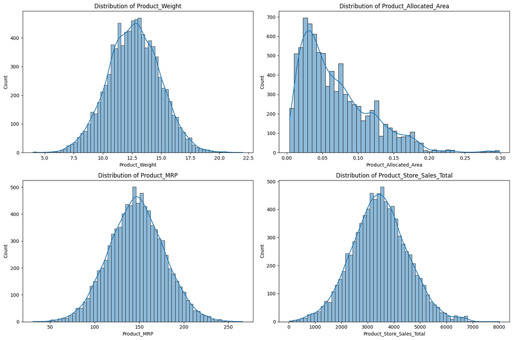

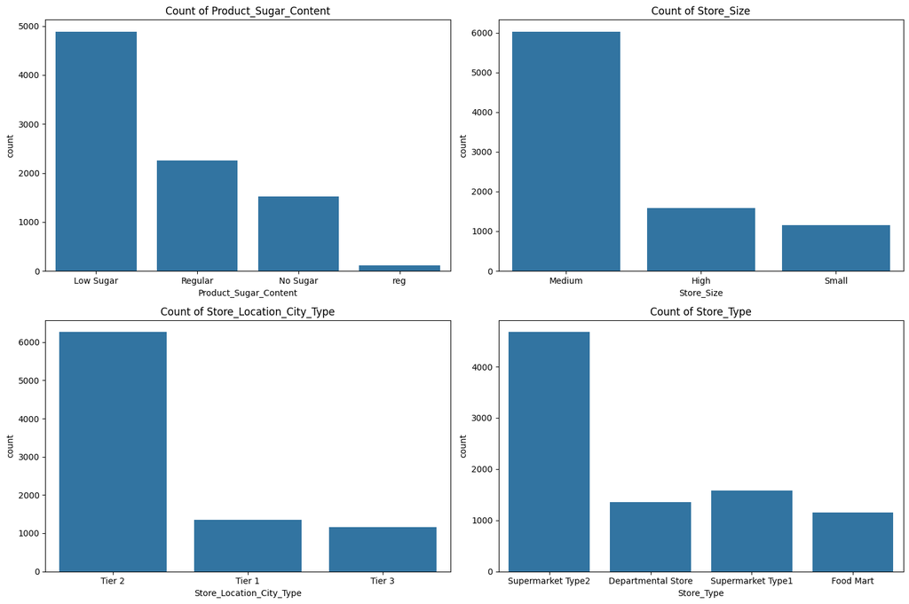

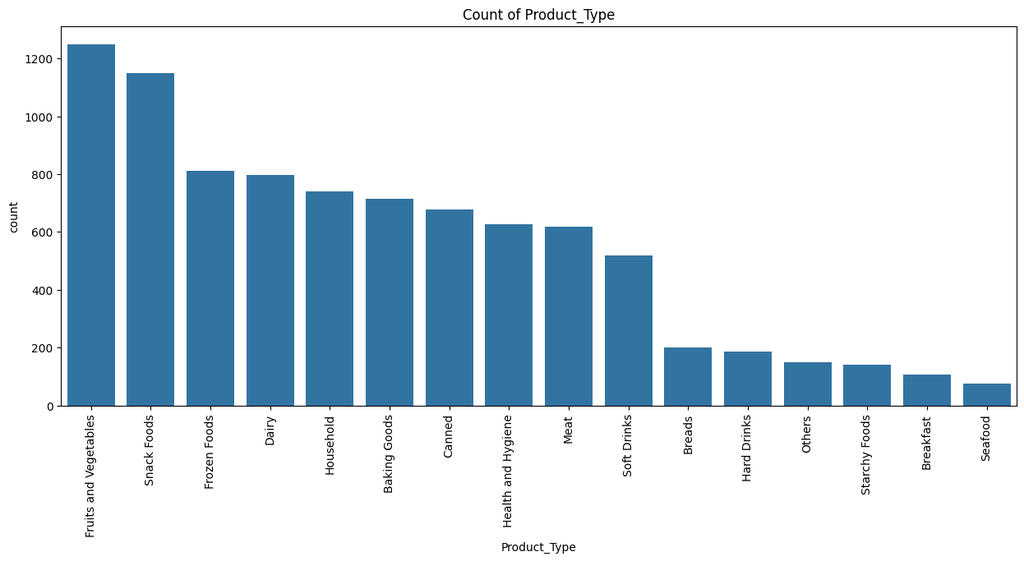

```python
# Statistical summary of numerical columns
display(dataset.describe())

# List of numerical columns to visualize
num_cols = ['Product_Weight', 'Product_Allocated_Area', 'Product_MRP', 'Product_Store_Sales_Total']

# Plotting distributions for numerical columns
plt.figure(figsize=(15, 10))
for i, col in enumerate(num_cols):
    plt.subplot(2, 2, i + 1)
    sns.histplot(dataset[col], kde=True)
    plt.title(f'Distribution of {col}')
plt.tight_layout()
plt.show()

# List of categorical columns to visualize (excluding Product_Type for now due to high cardinality)
cat_cols = ['Product_Sugar_Content', 'Store_Size', 'Store_Location_City_Type', 'Store_Type']

# Plotting counts for categorical columns
plt.figure(figsize=(15, 10))
for i, col in enumerate(cat_cols):
    plt.subplot(2, 2, i + 1)
    sns.countplot(data=dataset, x=col)
    plt.title(f'Count of {col}')
plt.tight_layout()
plt.show()

# Product Type requires a separate plot due to many categories
plt.figure(figsize=(15, 6))
sns.countplot(data=dataset, x='Product_Type', order=dataset['Product_Type'].value_counts().index)
plt.title('Count of Product_Type')
plt.xticks(rotation=90)
plt.show()
```

## Bivariate Analysis

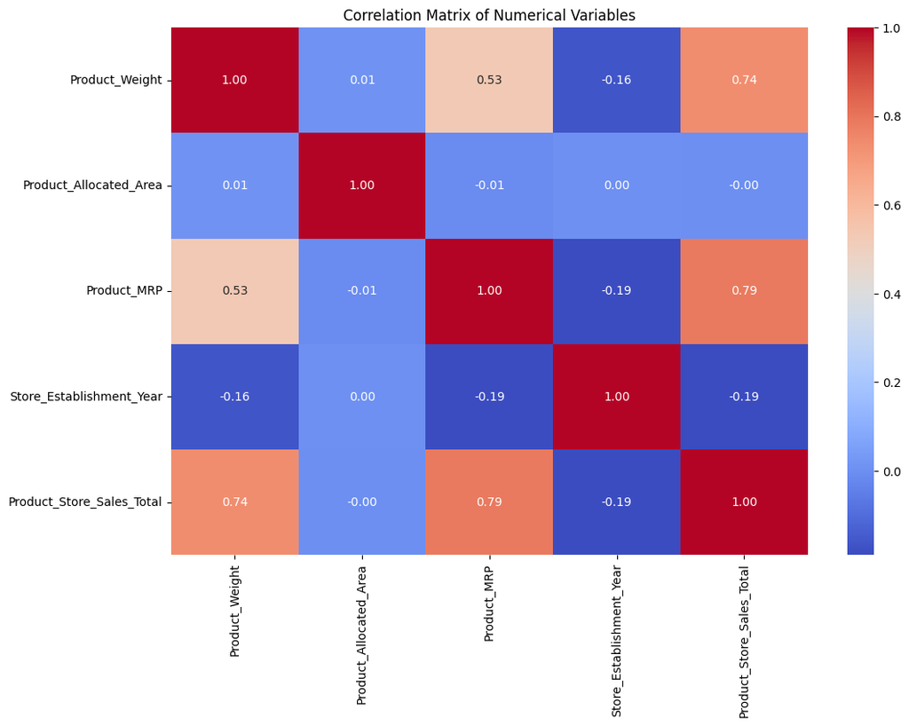

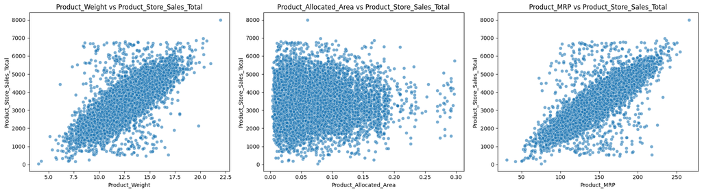

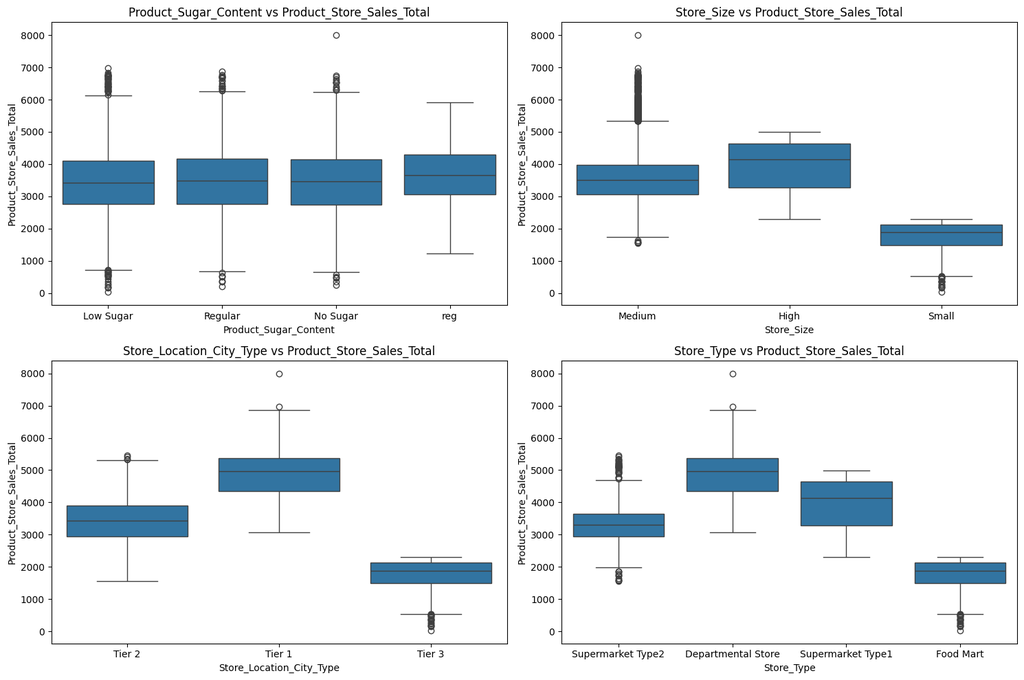

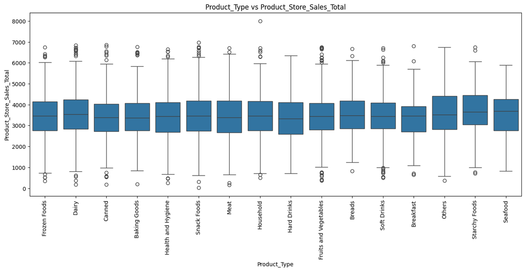

```python
# 1. Correlation Matrix Heatmap
plt.figure(figsize=(12, 8))
# Select only numeric columns for correlation calculation
numeric_data = dataset.select_dtypes(include=[np.number])
sns.heatmap(numeric_data.corr(), annot=True, cmap='coolwarm', fmt=".2f")
plt.title('Correlation Matrix of Numerical Variables')
plt.show()

# 2. Numerical Variables vs Target (Product_Store_Sales_Total)
num_features = ['Product_Weight', 'Product_Allocated_Area', 'Product_MRP']
target_col = 'Product_Store_Sales_Total'

plt.figure(figsize=(18, 5))
for i, col in enumerate(num_features):
    plt.subplot(1, 3, i + 1)
    sns.scatterplot(data=dataset, x=col, y=target_col, alpha=0.6)
    plt.title(f'{col} vs {target_col}')
plt.tight_layout()
plt.show()

# 3. Categorical Variables vs Target (Box Plots)
cat_features = ['Product_Sugar_Content', 'Store_Size', 'Store_Location_City_Type', 'Store_Type']

plt.figure(figsize=(15, 10))
for i, col in enumerate(cat_features):
    plt.subplot(2, 2, i + 1)
    sns.boxplot(data=dataset, x=col, y=target_col)
    plt.title(f'{col} vs {target_col}')
plt.tight_layout()
plt.show()

# 4. Product Type vs Target (Box Plot)
plt.figure(figsize=(16, 6))
sns.boxplot(data=dataset, x='Product_Type', y=target_col)
plt.title('Product_Type vs Product_Store_Sales_Total')
plt.xticks(rotation=90)
plt.show()
```

# **Data Preprocessing**

```python
# Replace 'reg' with 'Regular' in the Product_Sugar_Content column
dataset['Product_Sugar_Content'] = dataset['Product_Sugar_Content'].replace('reg', 'Regular')

# Create a new column named Product_Category by extracting the first two characters from the Product_Id column
dataset['Product_Category'] = dataset['Product_Id'].str[:2]

# Map the values in the new Product_Category column
dataset['Product_Category'] = dataset['Product_Category'].map({'FD': 'Food', 'NC': 'Non-Consumable', 'DR': 'Drinks'})

# Update the Product_Sugar_Content column to 'No Sugar' for all rows where the Product_Category is 'Non-Consumable'
dataset.loc[dataset['Product_Category'] == 'Non-Consumable', 'Product_Sugar_Content'] = 'No Sugar'

# Display the unique values of Product_Sugar_Content to verify the cleaning
print('Unique values in Product_Sugar_Content after cleaning:')
print(dataset['Product_Sugar_Content'].unique())

# Display the value counts of Product_Category to verify the feature engineering
print('\nValue counts of Product_Category:')
print(dataset['Product_Category'].value_counts())
```

```
Unique values in Product_Sugar_Content after cleaning:
['Low Sugar' 'Regular' 'No Sugar']

Value counts of Product_Category:
Product_Category
Food              6539
Non-Consumable    1519
Drinks             705
Name: count, dtype: int64
```

```python
# Drop irrelevant columns Product_Id and Store_Id
# Create a copy to avoid modifying the original dataset for this step
df_processed = dataset.drop(columns=['Product_Id', 'Store_Id']).copy()

# Define features (X) and target (y)
X = df_processed.drop('Product_Store_Sales_Total', axis=1)
y = df_processed['Product_Store_Sales_Total']

# Split the data into training and testing sets (70:30 ratio)
X_train, X_test, y_train, y_test = train_test_split(X, y, test_size=0.3, random_state=42)

print(f"X_train shape: {X_train.shape}")
print(f"X_test shape: {X_test.shape}")
print(f"y_train shape: {y_train.shape}")
print(f"y_test shape: {y_test.shape}")

# Identify numerical and categorical columns for preprocessing
# Exclude the target column and any IDs already dropped
numerical_cols = X_train.select_dtypes(include=np.number).columns.tolist()
categorical_cols = X_train.select_dtypes(include='object').columns.tolist()

# Create a ColumnTransformer for preprocessing
preprocessor = make_column_transformer(
    (StandardScaler(), numerical_cols),
    (OneHotEncoder(handle_unknown='ignore'), categorical_cols),
    remainder='passthrough' # Keep other columns (if any) as they are
)

print("\nNumerical Columns for Scaling:", numerical_cols)
print("Categorical Columns for One-Hot Encoding:", categorical_cols)
```

```
X_train shape: (6134, 10)
X_test shape: (2629, 10)
y_train shape: (6134,)
y_test shape: (2629,)

Numerical Columns for Scaling: ['Product_Weight', 'Product_Allocated_Area', 'Product_MRP', 'Store_Establishment_Year']
Categorical Columns for One-Hot Encoding: ['Product_Sugar_Content', 'Product_Type', 'Store_Size', 'Store_Location_City_Type', 'Store_Type', 'Product_Category']
```

# **Model Building**

## Define functions for Model Evaluation

```python
# function to compute adjusted R-squared
def adj_r2_score(predictors, targets, predictions):
    r2 = r2_score(targets, predictions)
    n = predictors.shape[0]
    k = predictors.shape[1]
    return 1 - ((1 - r2) * (n - 1) / (n - k - 1))


# function to compute different metrics to check performance of a regression model
def model_performance_regression(model, predictors, target):
    """
    Function to compute different metrics to check regression model performance

    model: regressor
    predictors: independent variables
    target: dependent variable
    """

    # predicting using the independent variables
    pred = model.predict(predictors)

    r2 = r2_score(target, pred)  # to compute R-squared
    adjr2 = adj_r2_score(predictors, target, pred)  # to compute adjusted R-squared
    rmse = np.sqrt(mean_squared_error(target, pred))  # to compute RMSE
    mae = mean_absolute_error(target, pred)  # to compute MAE
    mape = mean_absolute_percentage_error(target, pred)  # to compute MAPE

    # creating a dataframe of metrics
    df_perf = pd.DataFrame(
        {
            "RMSE": rmse,
            "MAE": mae,
            "R-squared": r2,
            "Adj. R-squared": adjr2,
            "MAPE": mape,
        },
        index=[0],
    )

    return df_perf
```

The ML models to be built can be any two out of the following:

1. Decision Tree
2. Bagging
3. Random Forest
4. AdaBoost
5. Gradient Boosting
6. XGBoost

```python
rf_model = RandomForestRegressor(random_state=42)
xgb_model = XGBRegressor(random_state=42)

print("RandomForestRegressor and XGBRegressor models initialized.")
```

```
RandomForestRegressor and XGBRegressor models initialized.
```

```python
rf_pipeline = make_pipeline(preprocessor, rf_model)
print("Fitting Random Forest Pipeline...")
rf_pipeline.fit(X_train, y_train)
print("Random Forest Pipeline fitted.")

xgb_pipeline = make_pipeline(preprocessor, xgb_model)
print("Fitting XGBoost Pipeline...")
xgb_pipeline.fit(X_train, y_train)
print("XGBoost Pipeline fitted.")
```

```
Fitting Random Forest Pipeline...
Random Forest Pipeline fitted.
Fitting XGBoost Pipeline...
XGBoost Pipeline fitted.
```

```python
print("Random Forest Model Performance:")
print("Train Performance:")
display(model_performance_regression(rf_pipeline, X_train, y_train))
print("Test Performance:")
display(model_performance_regression(rf_pipeline, X_test, y_test))

print("\nXGBoost Model Performance:")
print("Train Performance:")
display(model_performance_regression(xgb_pipeline, X_train, y_train))
print("Test Performance:")
display(model_performance_regression(xgb_pipeline, X_test, y_test))
```

```
Random Forest Model Performance:
Train Performance:
```

|  | RMSE | MAE | R-squared | Adj. R-squared | MAPE |
| --- | --- | --- | --- | --- | --- |
| 0 | 108.251322 | 41.491667 | 0.989678 | 0.989661 | 0.015612 |

```
Test Performance:
```

|  | RMSE | MAE | R-squared | Adj. R-squared | MAPE |
| --- | --- | --- | --- | --- | --- |
| 0 | 282.566697 | 107.610821 | 0.92969 | 0.929421 | 0.039246 |

```
XGBoost Model Performance:
Train Performance:
```

|  | RMSE | MAE | R-squared | Adj. R-squared | MAPE |
| --- | --- | --- | --- | --- | --- |
| 0 | 128.746905 | 63.000972 | 0.985399 | 0.985375 | 0.022315 |

```
Test Performance:
```

|  | RMSE | MAE | R-squared | Adj. R-squared | MAPE |
| --- | --- | --- | --- | --- | --- |
| 0 | 305.82645 | 137.147496 | 0.917638 | 0.917324 | 0.05001 |

# **Model Performance Improvement - Hyperparameter Tuning**

```python
rf_param_grid = {
    'randomforestregressor__n_estimators': [100, 200],
    'randomforestregressor__max_depth': [10, 20],
    'randomforestregressor__min_samples_leaf': [5, 10]
}

xgb_param_grid = {
    'xgbregressor__n_estimators': [100, 200],
    'xgbregressor__max_depth': [5, 10],
    'xgbregressor__learning_rate': [0.05, 0.1]
}

print("Hyperparameter grids defined for RandomForestRegressor and XGBoostRegressor.")
```

```
Hyperparameter grids defined for RandomForestRegressor and XGBoostRegressor.
```

```python
print("Starting GridSearchCV for RandomForestRegressor...")
# GridSearchCV for RandomForestRegressor
rf_grid_search = GridSearchCV(estimator=rf_pipeline, param_grid=rf_param_grid, cv=3, n_jobs=-1, verbose=2, scoring='neg_mean_squared_error')
rf_grid_search.fit(X_train, y_train)

print("GridSearchCV for RandomForestRegressor completed.")
print("Best parameters for RandomForestRegressor:", rf_grid_search.best_params_)
print("Best RMSE for RandomForestRegressor:", np.sqrt(-rf_grid_search.best_score_))
```

```
Starting GridSearchCV for RandomForestRegressor...
Fitting 3 folds for each of 8 candidates, totalling 24 fits
GridSearchCV for RandomForestRegressor completed.
Best parameters for RandomForestRegressor: {'randomforestregressor__max_depth': 20, 'randomforestregressor__min_samples_leaf': 5, 'randomforestregressor__n_estimators': 200}
Best RMSE for RandomForestRegressor: 293.67107977103825
```

```python
print("Starting GridSearchCV for XGBoostRegressor...")
# GridSearchCV for XGBoostRegressor
xgb_grid_search = GridSearchCV(estimator=xgb_pipeline, param_grid=xgb_param_grid, cv=3, n_jobs=-1, verbose=2, scoring='neg_mean_squared_error')
xgb_grid_search.fit(X_train, y_train)

print("GridSearchCV for XGBoostRegressor completed.")
print("Best parameters for XGBoostRegressor:", xgb_grid_search.best_params_)
print("Best RMSE for XGBoostRegressor:", np.sqrt(-xgb_grid_search.best_score_))
```

```
Starting GridSearchCV for XGBoostRegressor...
Fitting 3 folds for each of 8 candidates, totalling 24 fits
GridSearchCV for XGBoostRegressor completed.
Best parameters for XGBoostRegressor: {'xgbregressor__learning_rate': 0.1, 'xgbregressor__max_depth': 5, 'xgbregressor__n_estimators': 100}
Best RMSE for XGBoostRegressor: 298.9317185667573
```

```python
print("Random Forest Tuned Model Performance:")
print("Train Performance:")
display(model_performance_regression(rf_grid_search.best_estimator_, X_train, y_train))
print("Test Performance:")
display(model_performance_regression(rf_grid_search.best_estimator_, X_test, y_test))
```

```
Random Forest Tuned Model Performance:
Train Performance:
```

|  | RMSE | MAE | R-squared | Adj. R-squared | MAPE |
| --- | --- | --- | --- | --- | --- |
| 0 | 226.55805 | 82.099403 | 0.954787 | 0.954713 | 0.032056 |

```
Test Performance:
```

|  | RMSE | MAE | R-squared | Adj. R-squared | MAPE |
| --- | --- | --- | --- | --- | --- |
| 0 | 277.574513 | 103.897033 | 0.932152 | 0.931893 | 0.039598 |

```python
print("XGBoost Tuned Model Performance:")
print("Train Performance:")
display(model_performance_regression(xgb_grid_search.best_estimator_, X_train, y_train))
print("Test Performance:")
display(model_performance_regression(xgb_grid_search.best_estimator_, X_test, y_test))
```

```
XGBoost Tuned Model Performance:
Train Performance:
```

|  | RMSE | MAE | R-squared | Adj. R-squared | MAPE |
| --- | --- | --- | --- | --- | --- |
| 0 | 232.878935 | 98.895356 | 0.952229 | 0.952151 | 0.037198 |

```
Test Performance:
```

|  | RMSE | MAE | R-squared | Adj. R-squared | MAPE |
| --- | --- | --- | --- | --- | --- |
| 0 | 283.8919 | 123.157246 | 0.929029 | 0.928758 | 0.045633 |

# **Model Performance Comparison, Final Model Selection, and Serialization**

```python
# Calculate training performance for each model
rf_estimator_model_train_perf = model_performance_regression(rf_pipeline, X_train, y_train)
rf_tuned_model_train_perf = model_performance_regression(rf_grid_search.best_estimator_, X_train, y_train)
xgb_estimator_model_train_perf = model_performance_regression(xgb_pipeline, X_train, y_train)
xgb_tuned_model_train_perf = model_performance_regression(xgb_grid_search.best_estimator_, X_train, y_train)

# training performance comparison
models_train_comp_df = pd.concat(
    [
        rf_estimator_model_train_perf.T,
        rf_tuned_model_train_perf.T,
        xgb_estimator_model_train_perf.T,
        xgb_tuned_model_train_perf.T
    ],
    axis=1,
)

models_train_comp_df.columns = [
    "Random Forest Estimator",
    "Random Forest Tuned",
    "XGBoost",
    "XGBoost Tuned"
]

print("Training performance comparison:")
display(models_train_comp_df)
```

```
Training performance comparison:
```

|  | Random Forest Estimator | Random Forest Tuned | XGBoost | XGBoost Tuned |
| --- | --- | --- | --- | --- |
| RMSE | 108.251322 | 226.558050 | 128.746905 | 232.878935 |
| MAE | 41.491667 | 82.099403 | 63.000972 | 98.895356 |
| R-squared | 0.989678 | 0.954787 | 0.985399 | 0.952229 |
| Adj. R-squared | 0.989661 | 0.954713 | 0.985375 | 0.952151 |
| MAPE | 0.015612 | 0.032056 | 0.022315 | 0.037198 |

```python
# Calculate testing performance for each model
rf_estimator_model_test_perf = model_performance_regression(rf_pipeline, X_test, y_test)
rf_tuned_model_test_perf = model_performance_regression(rf_grid_search.best_estimator_, X_test, y_test)
xgb_estimator_model_test_perf = model_performance_regression(xgb_pipeline, X_test, y_test)
xgb_tuned_model_test_perf = model_performance_regression(xgb_grid_search.best_estimator_, X_test, y_test)

# Testing performance comparison
models_test_comp_df = pd.concat(
    [rf_estimator_model_test_perf.T,
    rf_tuned_model_test_perf.T,
    xgb_estimator_model_test_perf.T,
    xgb_tuned_model_test_perf.T],
    axis=1,
)

models_test_comp_df.columns = [
    "Random Forest Estimator",
    "Random Forest Tuned",
    "XGBoost",
    "XGBoost Tuned"
]

print("Testing performance comparison:")
display(models_test_comp_df)
```

```
Testing performance comparison:
```

|  | Random Forest Estimator | Random Forest Tuned | XGBoost | XGBoost Tuned |
| --- | --- | --- | --- | --- |
| RMSE | 282.566697 | 277.574513 | 305.826450 | 283.891900 |
| MAE | 107.610821 | 103.897033 | 137.147496 | 123.157246 |
| R-squared | 0.929690 | 0.932152 | 0.917638 | 0.929029 |
| Adj. R-squared | 0.929421 | 0.931893 | 0.917324 | 0.928758 |
| MAPE | 0.039246 | 0.039598 | 0.050010 | 0.045633 |

```python
# Display the gap between the R-squared of Train vs. Test for each model.
(models_train_comp_df - models_test_comp_df).iloc[2]
```

|  | R-squared |
| --- | --- |
| Random Forest Estimator | 0.059988 |
| Random Forest Tuned | 0.022635 |
| XGBoost | 0.067761 |
| XGBoost Tuned | 0.023200 |

**dtype:** float64

Based on the comprehensive model performance comparison on the test dataset, the Tuned Random Forest Model has been selected as the final model for this project. Here's why:

1. Lower RMSE and MAE: The Tuned Random Forest model achieved the lowest Root Mean Squared Error (RMSE) of 277.57 and Mean Absolute Error (MAE) of 103.90 on the test set. These metrics indicate that its predictions are, on average, closer to the actual sales values, signifying better accuracy.
2. Higher R-squared: It also exhibited the highest R-squared value of 0.9322 on the test set. A higher R-squared suggests that the model explains a larger proportion of the variance in the target variable (Product_Store_Sales_Total), indicating a better fit to unseen data.
3. Better Generalization: The gap between its training R-squared (0.9548) and test R-squared (0.9322) is approximately 0.0226. This is slightly smaller than the Tuned XGBoost model's gap (0.0232), indicating slightly better generalization and less overfitting compared to the tuned XGBoost model.
4. Overall Robustness: While both tuned models performed well, the marginal improvements in RMSE, MAE, and R-squared for the Tuned Random Forest model make it the preferred choice for deployment.

```python
# Serialize the best model (Tuned Random Forest Model)
model_filename = 'best_random_forest_model.joblib'

# Define the full path for saving the model in Google Drive
model_save_path = f'/content/drive/My Drive/Colab Notebooks/SuperKart/{model_filename}'

joblib.dump(rf_grid_search.best_estimator_, model_save_path)
print(f"Tuned Random Forest Model serialized and saved to Google Drive as {model_save_path}")

# Add line to download the file to the local machine
from google.colab import files
files.download(model_save_path)

# --- Sanity Check ---
# Load the model back to ensure it works
loaded_model = joblib.load(model_save_path) # Load from the new path
print(f"\nModel loaded successfully from {model_save_path}")

# Select a random sample from X_test for prediction
sample_index = np.random.randint(0, len(X_test))
sample_X = X_test.iloc[[sample_index]]
sample_y_actual = y_test.iloc[sample_index]

# Make a prediction with the loaded model
sample_prediction = loaded_model.predict(sample_X)

print(f"\nSanity Check:")
print(f"  Sample input: {sample_X.to_dict(orient='records')[0]}")
print(f"  Actual Sales Total: {sample_y_actual:.2f}")
print(f"  Predicted Sales Total: {sample_prediction[0]:.2f}")
print(f"  Difference: {abs(sample_y_actual - sample_prediction[0]):.2f}")
```

```
Tuned Random Forest Model serialized and saved to Google Drive as /content/drive/My Drive/Colab Notebooks/SuperKart/best_random_forest_model.joblib
```

[output not shown]

# **Deployment - Backend**

```python
import os

# Create the directory for backend files
if not os.path.exists('backend_files'):
    os.makedirs('backend_files')
    print("Directory 'backend_files' created.")
else:
    print("Directory 'backend_files' already exists.")
```

```
Directory 'backend_files' created.
```

## Flask Web Framework

```python
%%writefile backend_files/app.py
import os
from flask import Flask, request, jsonify
import joblib
import pandas as pd
import numpy as np

app = Flask(__name__)

# Get the directory where app.py is located
base_dir = os.path.dirname(os.path.abspath(__file__))

# Construct the full path to the model file
# Assuming the model is in the same directory as app.py within the Docker container
model_path = os.path.join(base_dir, 'best_random_forest_model.joblib')

# Load the model
try:
    model = joblib.load(model_path)
    print(f"Model loaded successfully from {model_path}")
except Exception as e:
    print(f"Error loading model: {e}")
    model = None

@app.route('/')
def home():
    return "SuperKart Sales Prediction API"

@app.route('/predict', methods=['POST'])
def predict():
    if model is None:
        return jsonify({'error': 'Model not loaded'}), 500

    try:
        json_ = request.json
        # Define the expected features (columns in the order expected by the preprocessor)
        required_features = [
            'Product_Weight', 'Product_Sugar_Content', 'Product_Allocated_Area',
            'Product_Type', 'Product_MRP', 'Store_Establishment_Year',
            'Store_Size', 'Store_Location_City_Type', 'Store_Type', 'Product_Category'
        ]

        # If input is a list of dictionaries (for batch prediction)
        if isinstance(json_, list):
            data = pd.DataFrame(json_, columns=required_features)
        else: # Single prediction
            data = pd.DataFrame([json_], columns=required_features)

        # Make prediction
        prediction = model.predict(data)

        # Return predictions as JSON
        return jsonify({'prediction': prediction.tolist()})

    except Exception as e:
        return jsonify({'error': str(e)}), 400

if __name__ == '__main__':
    app.run(debug=True, host='0.0.0.0', port=5000)
```

```
Writing backend_files/app.py
```

## Dependencies File

```python
%%writefile backend_files/requirements.txt
Flask
scikit-learn
numpy
pandas
joblib
```

```
Writing backend_files/requirements.txt
```

## Dockerfile

```python
%%writefile backend_files/Dockerfile
# Use a suitable base image
FROM python:3.9-slim

# Set the working directory inside the container
WORKDIR /app

# Copy the requirements file and install dependencies
COPY requirements.txt .
RUN pip install --no-cache-dir -r requirements.txt

# Copy the application code and the trained model
# Assuming best_random_forest_model.joblib is available in the Colab environment
COPY app.py .
COPY best_random_forest_model.joblib .

# Expose the port the Flask app will run on
EXPOSE 5000

# Command to run the Flask application
CMD ["python", "app.py"]
```

```
Writing backend_files/Dockerfile
```

## Setting up a Hugging Face Docker Space for the Backend

**Instructions:**

1. **Define your Hugging Face Username and Space Name**: Replace `<YOUR_HF_USERNAME>` with your actual Hugging Face username in the code cell below.
2. **Upload Files**: Run the code cell to log in to Hugging Face and upload the `backend_files` directory to your pre-created Docker Space.

```python
from huggingface_hub import HfApi

# Define your Hugging Face access token directly (NOT RECOMMENDED FOR PRODUCTION)
HF_TOKEN = "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"

# Initialize HfApi with the token
api = HfApi(token=HF_TOKEN)

# Define your Hugging Face username and the desired space name
HF_USERNAME = "SkylineLofe"  # Replace with your Hugging Face username
HF_BACKEND_SPACE_NAME = "SkylineLofe_BackEnd3" # This should match your pre-created Docker Space name

# Construct the repo_id
repo_id = f"{HF_USERNAME}/{HF_BACKEND_SPACE_NAME}"

# Path to the directory containing your backend files
local_folder_path = "backend_files"

# Upload the entire folder to the Hugging Face Space
try:
    api.upload_folder(
        repo_id=repo_id,
        folder_path=local_folder_path,
        path_in_repo=".",  # Uploads contents directly to the root of the space
        repo_type="space",
        commit_message="Upload backend files for SuperKart sales prediction API"
    )
    print(f"Successfully uploaded files to Hugging Face Space: {repo_id}")
except Exception as e:
    print(f"Error uploading files to Hugging Face Space: {e}")
```

```
No files have been modified since last commit. Skipping to prevent empty commit.
WARNING:huggingface_hub.hf_api:No files have been modified since last commit. Skipping to prevent empty commit.
```

```
Successfully uploaded files to Hugging Face Space: SkylineLofe/SkylineLofe_BackEnd3
```